# JELSCH BOND 2_0_0.15_10_Difference

## Slices along x,y and z

Sliced x-wise

Sliced y-wise

Sliced z-wise

33/67

33/67

33/67

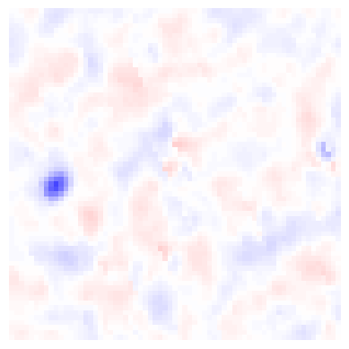

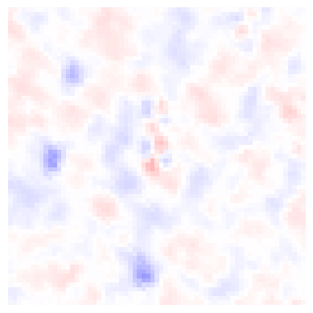

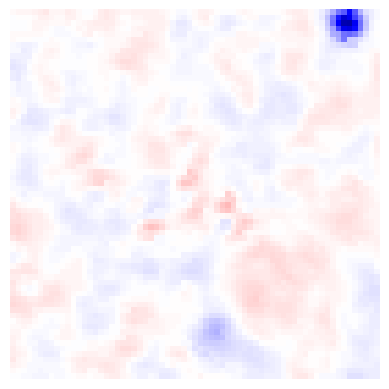

## Sample=1ejg-a:22:c-a:23:n-a:22:o

| pdb_code | central atom | ca density | parallel atom | pa density | planar atom | pl density |
| --- | --- | --- | --- | --- | --- | --- |
| 1ejg | [6.39, 13.12, -1.16] | -5.3996 | [7.65, 13.19, -0.86] | 6.0919 | [5.48, 13.01, -0.34] | -22.5715 |

## Slices along x,y and z

Sliced x-wise

Sliced y-wise

Sliced z-wise

33/67

33/67

33/67

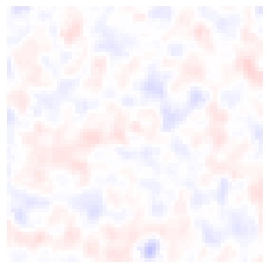

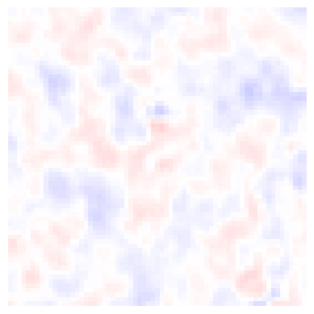

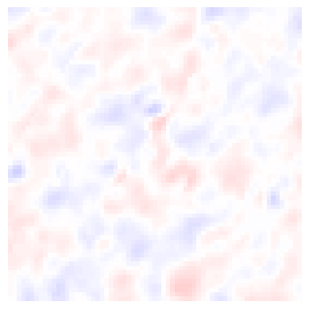

## Sample=1ejg-a:6:c-a:7:n-a:6:o

| pdb_code | central atom | ca density | parallel atom | pa density | planar atom | pl density |
| --- | --- | --- | --- | --- | --- | --- |
| 1ejg | [8.83, 4.43, 14.01] | 4.2523 | [8.94, 3.13, 14.3] | -16.4319 | [8.76, 4.87, 12.86] | 11.512 |

## Slices along x,y and z

Sliced x-wise

Sliced y-wise

Sliced z-wise

33/67

33/67

33/67

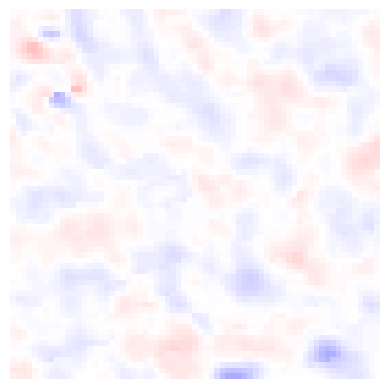

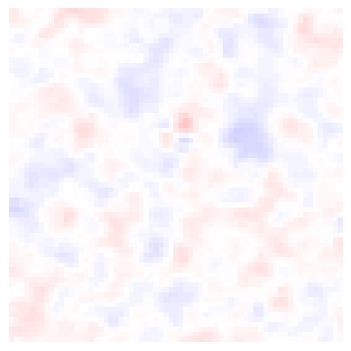

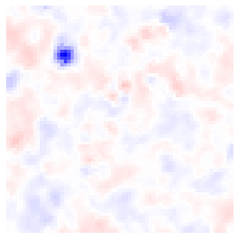

## Sample=1ejg-a:23:c-a:24:n-a:23:o

| pdb_code | central atom | ca density | parallel atom | pa density | planar atom | pl density |
| --- | --- | --- | --- | --- | --- | --- |
| 1ejg | [7.39, 13.97, 1.46] | 7.5936 | [7.19, 15.23, 1.04] | 4.2176 | [7.06, 13.59, 2.59] | -5.6792 |

## Slices along x,y and z

Sliced x-wise

Sliced y-wise

Sliced z-wise

33/67

33/67

33/67

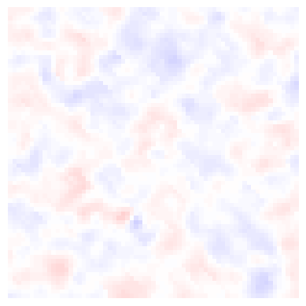

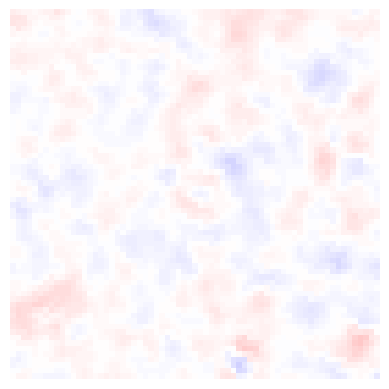

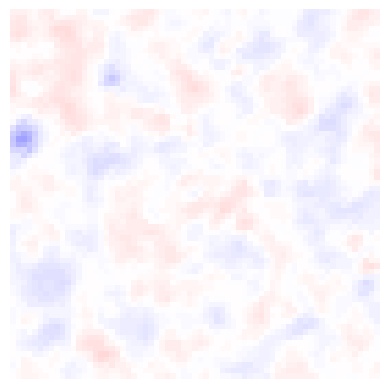

## Sample=1ejg-a:20:c-a:21:n-a:20:o

| pdb_code | central atom | ca density | parallel atom | pa density | planar atom | pl density |
| --- | --- | --- | --- | --- | --- | --- |
| 1ejg | [4.9, 9.47, -5.25] | 23.5786 | [4.06, 9.4, -4.22] | 10.7153 | [5.44, 10.51, -5.62] | -1.134 |

## Slices along x,y and z

Sliced x-wise

Sliced y-wise

Sliced z-wise

33/67

33/67

33/67

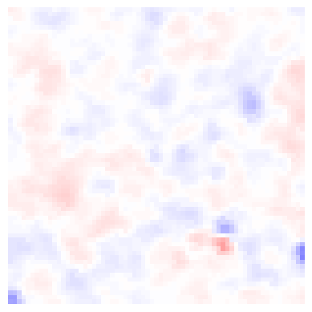

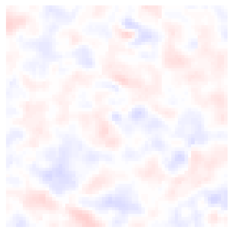

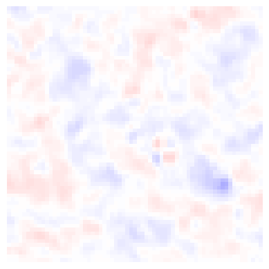

## Sample=1ejg-a:8:c-a:9:n-a:8:o

| pdb_code | central atom | ca density | parallel atom | pa density | planar atom | pl density |
| --- | --- | --- | --- | --- | --- | --- |
| 1ejg | [5.21, 3.39, 11.37] | 1.6857 | [5.67, 4.56, 11.85] | 8.6022 | [4.71, 3.3, 10.24] | -14.8505 |

## Slices along x,y and z

Sliced x-wise

Sliced y-wise

Sliced z-wise

33/67

33/67

33/67

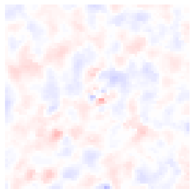

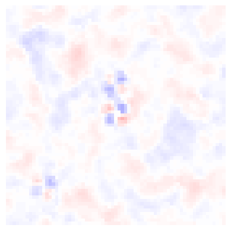

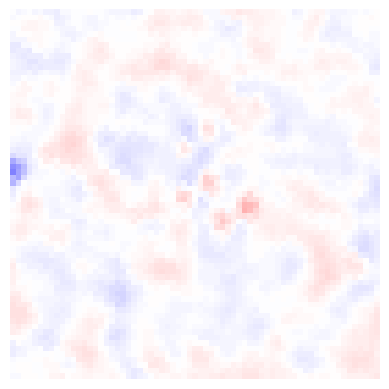

## Sample=1ejg-a:32:c-a:33:n-a:32:o

| pdb_code | central atom | ca density | parallel atom | pa density | planar atom | pl density |
| --- | --- | --- | --- | --- | --- | --- |
| 1ejg | [8.38, 13.05, 9.13] | -19.2932 | [9.69, 13.31, 8.99] | -18.877 | [7.49, 13.85, 8.92] | -2.7327 |

## Slices along x,y and z

Sliced x-wise

Sliced y-wise

Sliced z-wise

33/67

33/67

33/67

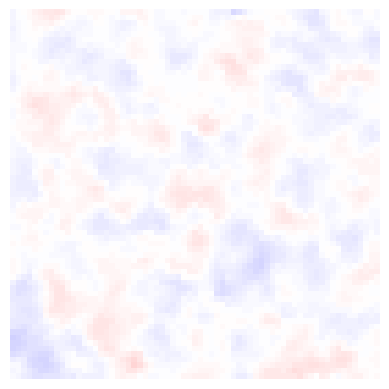

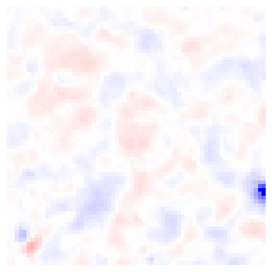

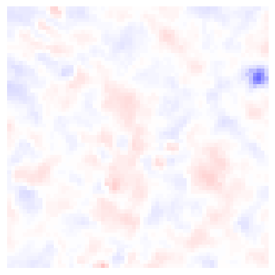

## Sample=1ejg-a:44:c-a:45:n-a:44:o

| pdb_code | central atom | ca density | parallel atom | pa density | planar atom | pl density |
| --- | --- | --- | --- | --- | --- | --- |
| 1ejg | [14.25, 9.66, 14.44] | 1.7698 | [14.35, 8.61, 15.27] | 3.958 | [14.93, 9.81, 13.43] | 8.6137 |

## Slices along x,y and z

Sliced x-wise

Sliced y-wise

Sliced z-wise

33/67

33/67

33/67

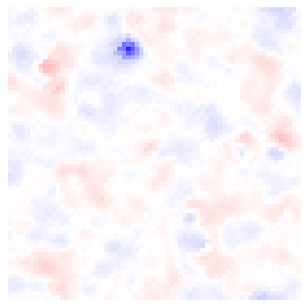

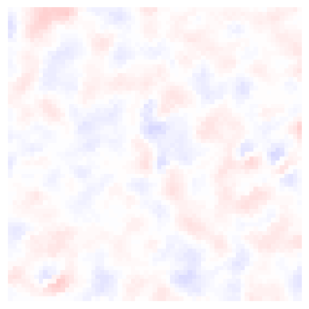

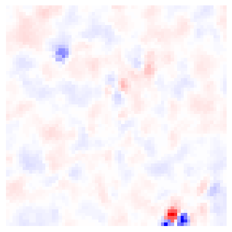

## Sample=1ejg-a:9:c-a:10:n-a:9:o

| pdb_code | central atom | ca density | parallel atom | pa density | planar atom | pl density |
| --- | --- | --- | --- | --- | --- | --- |
| 1ejg | [6.5, 5.51, 9.74] | 1.8218 | [7.68, 4.9, 9.9] | 14.2889 | [6.09, 5.89, 8.64] | 14.0139 |

## Slices along x,y and z

Sliced x-wise

Sliced y-wise

Sliced z-wise

33/67

33/67

33/67

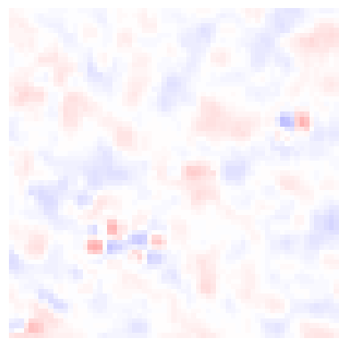

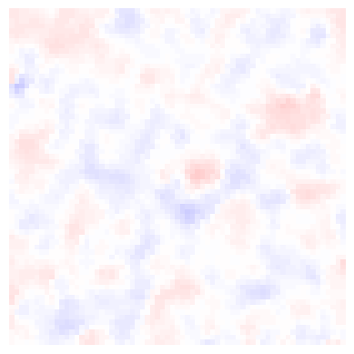

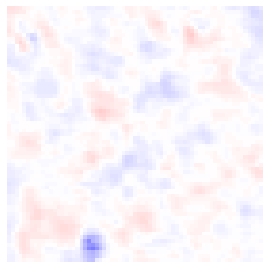

## Sample=1ejg-a:33:c-a:34:n-a:33:o

| pdb_code | central atom | ca density | parallel atom | pa density | planar atom | pl density |
| --- | --- | --- | --- | --- | --- | --- |
| 1ejg | [11.24, 14.53, 7.58] | -4.0773 | [11.45, 15.66, 6.91] | 5.9222 | [11.87, 13.48, 7.38] | -1.6835 |

## Slices along x,y and z

Sliced x-wise

Sliced y-wise

Sliced z-wise

33/67

33/67

33/67

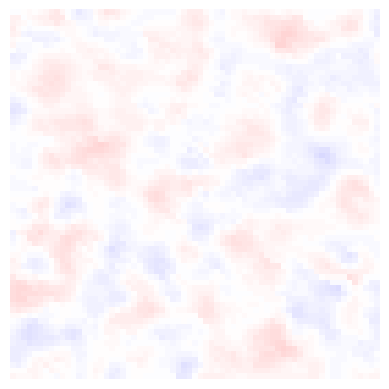

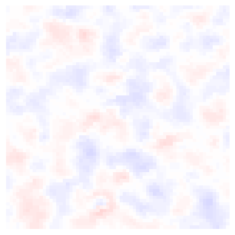

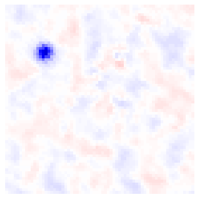

## Sample=1ejg-a:7:c-a:8:n-a:7:o

| pdb_code | central atom | ca density | parallel atom | pa density | planar atom | pl density |
| --- | --- | --- | --- | --- | --- | --- |
| 1ejg | [7.56, 2.14, 12.46] | -20.1045 | [6.38, 2.22, 13.07] | -11.2231 | [7.57, 2.12, 11.2] | -14.233 |

## Slices along x,y and z

Sliced x-wise

Sliced y-wise

Sliced z-wise

33/67

33/67

33/67

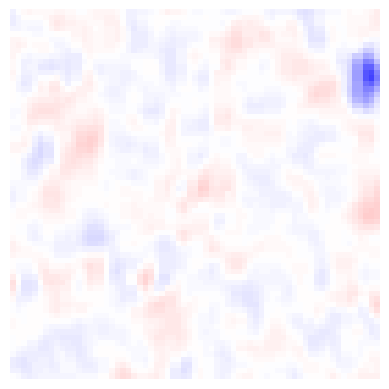

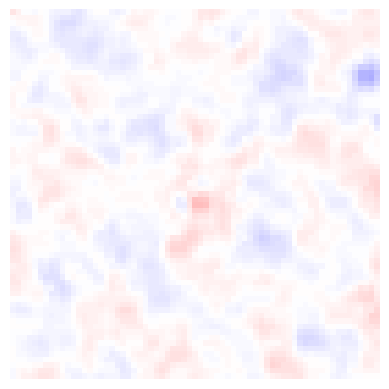

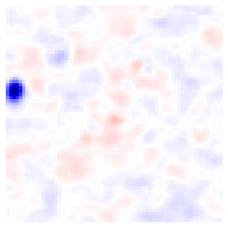

## Sample=1ejg-a:45:c-a:46:n-a:45:o

| pdb_code | central atom | ca density | parallel atom | pa density | planar atom | pl density |
| --- | --- | --- | --- | --- | --- | --- |
| 1ejg | [15.18, 6.5, 14.2] | -1.2433 | [13.97, 6.43, 13.64] | -7.6802 | [16.09, 5.7, 13.99] | -5.7711 |

## Slices along x,y and z

Sliced x-wise

Sliced y-wise

Sliced z-wise

33/67

33/67

33/67

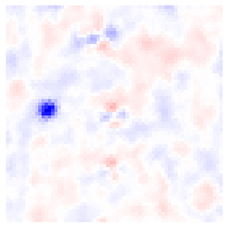

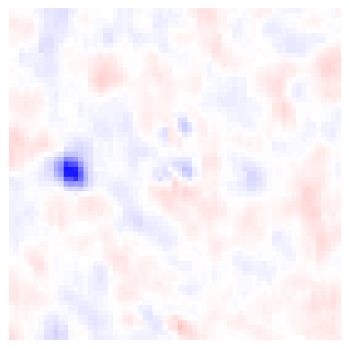

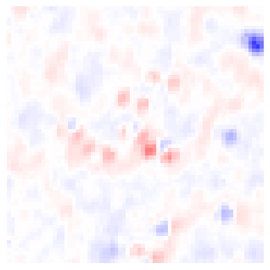

## Sample=1ejg-a:3:c-a:4:n-a:3:o

| pdb_code | central atom | ca density | parallel atom | pa density | planar atom | pl density |
| --- | --- | --- | --- | --- | --- | --- |
| 1ejg | [12.21, 10.41, 10.16] | 3.0847 | [12.02, 9.28, 10.85] | 5.8007 | [11.32, 11.25, 10.0] | -9.4889 |

## Slices along x,y and z

Sliced x-wise

Sliced y-wise

Sliced z-wise

33/67

33/67

33/67

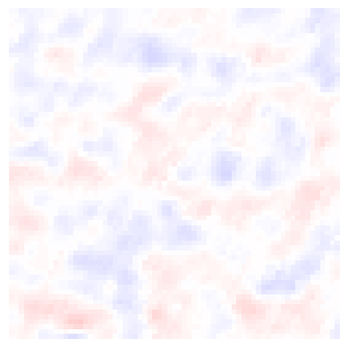

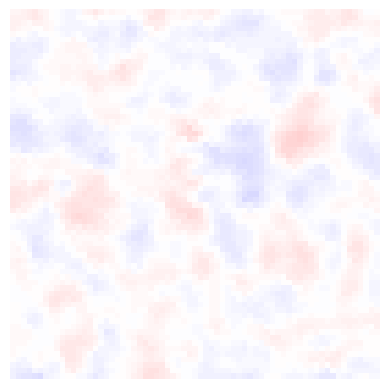

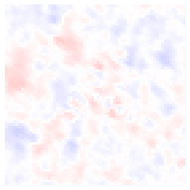

## Sample=1ejg-a:31:c-a:32:n-a:31:o

| pdb_code | central atom | ca density | parallel atom | pa density | planar atom | pl density |
| --- | --- | --- | --- | --- | --- | --- |
| 1ejg | [6.23, 12.15, 11.04] | 20.341 | [6.67, 11.51, 9.95] | -5.117 | [6.99, 12.66, 11.86] | 8.0652 |

## Slices along x,y and z

Sliced x-wise

Sliced y-wise

Sliced z-wise

33/67

33/67

33/67

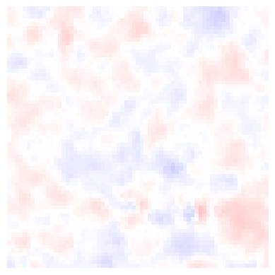

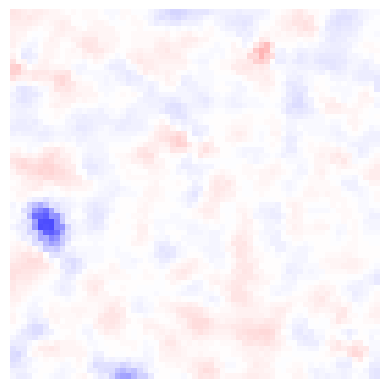

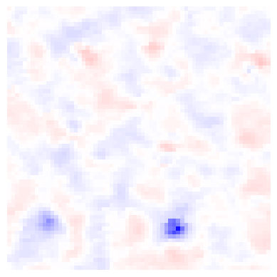

## Sample=1ejg-a:34:c-a:35:n-a:34:o

| pdb_code | central atom | ca density | parallel atom | pa density | planar atom | pl density |
| --- | --- | --- | --- | --- | --- | --- |
| 1ejg | [13.51, 16.81, 6.47] | -20.7362 | [14.79, 16.46, 6.44] | -10.2184 | [13.1, 17.91, 6.9] | -23.5886 |

## Slices along x,y and z

Sliced x-wise

Sliced y-wise

Sliced z-wise

33/67

33/67

33/67

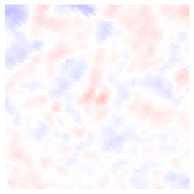

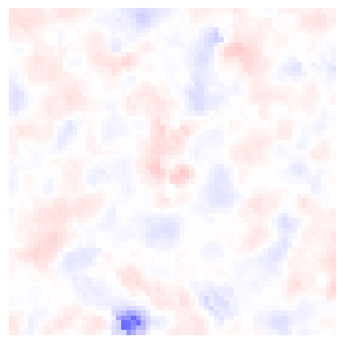

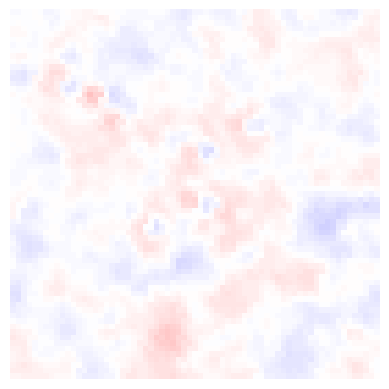

## Sample=1ejg-a:2:c-a:3:n-a:2:o

| pdb_code | central atom | ca density | parallel atom | pa density | planar atom | pl density |
| --- | --- | --- | --- | --- | --- | --- |
| 1ejg | [14.17, 10.76, 7.22] | -1.1801 | [13.44, 11.19, 8.26] | -4.5455 | [15.01, 9.86, 7.32] | 6.7791 |